# Statistical Inference Course Projects

Part I. Simulation Exercise

Rohan

August 12th, 2019

# Overview

The Central Limit Theorem will be explored in this exercise. The data will be 1000 simulations, each consisting of 40 observations exponentially distributed. The sample mean and variance will be compared to the theoretical mean and variance.

# Simulations

This simulation creates a data frame of the means and variances of 1000 simulations of 40 observations of an exponential distribution with lambda = 0.2. The means and variances of the last five simulations have been displayed.

```
##         Means Variances
## 996  4.407140  22.79438
## 997  4.963208  20.17653
## 998  5.363276  25.15128
## 999  5.167646  25.76569
## 1000 5.369561  43.64255
```

# Sample Mean vs Theoretical Mean

This histogram represents the spread of the means from the 1000 simulations. The average mean is very close to 5, the theoretical mean. The means seem to follow a normal distribution.

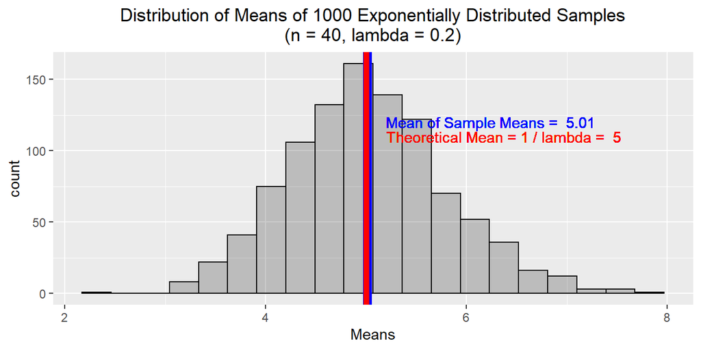

# Sample Variance vs Theoretical Variance

This histogram represents the spread of the variances from the 1000 simulations. The average variance is very close to 25, the theoretical variance. The variances seem to be skewed to the right.

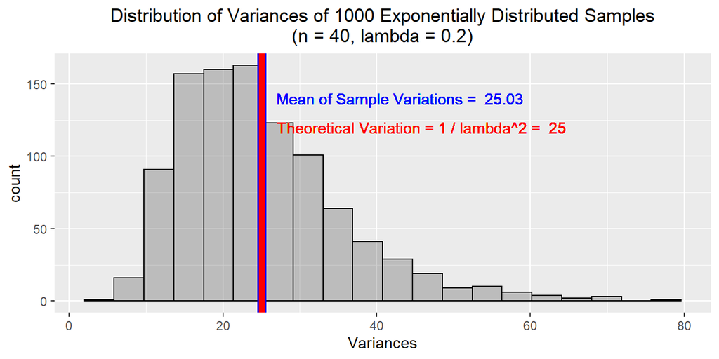

# Distribution

On the left is the distribution of 1000 exponentially distributed observations. The values are skewed to the right. On the right is the distribution of the 1000 means from our previous simulation, which approach a normal distribution. This is conveying the Central Limit Theorem, that is that the means of the variables are approaching a normal distribution, even if the individual variables are not normally distributed.

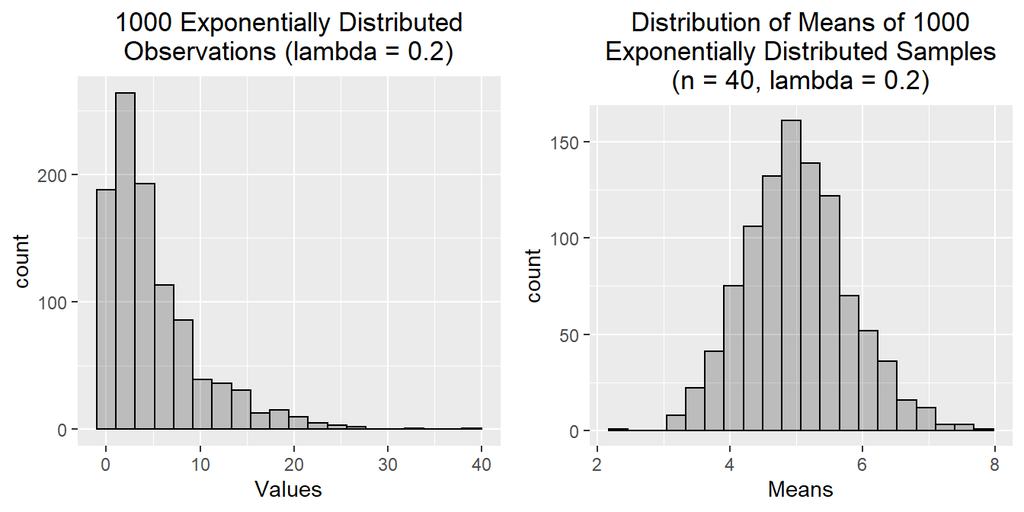

# Appendix

R code for all parts of the Simulation exercise.

```r
knitr::opts_chunk$set(echo = FALSE)
library(ggplot2)
library(gridExtra)

###Simulations
lambda <- 0.2
ExpData <- setNames(data.frame(matrix(ncol = 2, nrow = 0)),
                    c("Means", "Variances"))
for (i in 1:1000) {
    TempData <- rexp(40, lambda)
    ExpData[i, 1] <- mean(TempData)
    ExpData[i, 2] <- var(TempData)
    }

tail(ExpData, 5)

###Sample Mean vs Theoretical Mean
gM <- ggplot(ExpData, aes(Means))

gM <- gM + geom_histogram(bins = 20, color = "black",
                          fill = "black", alpha = 0.2)
gM3 <- gM + theme(plot.title = element_text(hjust = 0.5))

gM <- gM3 + ggtitle("Distribution of Means of 1000 Exponentially Distributed Samples
(n = 40, lambda = 0.2)")
gM <- gM + geom_vline(xintercept = mean(ExpData$Means), color = "blue",
                      linetype = "solid", size = 3)
gM <- gM + geom_vline(xintercept = 1 / lambda, color = "red",
                      linetype = "solid", size = 2)
gM <- gM + geom_text(x = 5.2, y = 120,
                     label = paste("Mean of Sample Means = ",
                                   round(mean(ExpData$Means), digits = 2)),
                     color = "blue", hjust = 0)
gM <- gM + geom_text(x = 5.2, y = 110,
                     label = paste("Theoretical Mean = 1 / lambda = ", (1 / lambda)),
                     color = "red", hjust = 0)
gM

###Sample Variance vs Theoretical Variance
gV <- ggplot(ExpData, aes(Variances))

gV <- gV + geom_histogram(bins = 20, color = "black",
                          fill = "black", alpha = 0.2)
gV <- gV + theme(plot.title = element_text(hjust = 0.5))

gV <- gV + ggtitle("Distribution of Variances of 1000 Exponentially Distributed Samples
(n = 40, lambda = 0.2)")
gV <- gV + geom_vline(xintercept = mean(ExpData$Variances), color = "blue",
                            linetype = "solid", size = 3)
gV <- gV + geom_vline(xintercept = 1 / lambda ^ 2, color = "red",
                      linetype = "solid",  size = 2)
gV <- gV + geom_text(x = 27, y = 140,
                     label = paste("Mean of Sample Variations = ",
                                   round(mean(ExpData$Variances), digits = 2)),
                     color = "blue", hjust = 0)
gV <- gV + geom_text(x = 27, y = 120,
                     label = paste("Theoretical Variation = 1 / lambda^2 = ", (1 / lambda^2)),
                     color = "red", hjust = 0)
gV

###Distribution
ExpData2 <- data.frame(rexp(1000, lambda))
colnames(ExpData2)<- "Values"
expSim <- ggplot(ExpData2, aes(Values))
expSim <- expSim + geom_histogram(bins = 20, color = "black",
                                  fill = "black", alpha = 0.2)
expSim <- expSim + theme(plot.title = element_text(hjust = 0.5))

expSim <- expSim + ggtitle("1000 Exponentially Distributed
Observations (lambda = 0.2)")

gM3 <- gM3 + ggtitle("Distribution of Means of 1000
Exponentially Distributed Samples
(n = 40, lambda = 0.2)")
grid.arrange(expSim, gM3, nrow = 1)
```